# Reducing Fragmentation

## Introduction

In many spatial planning problems, we are not only interested in meeting conservation targets at minimum cost, but also in **how fragmented** the selected areas are. Fragmented solutions can be difficult to manage, may fail to support viable populations, and are often harder to communicate to stakeholders.

This vignette explores different ways to **reduce fragmentation** in a typical prioritizr / spatialplanr workflow, using the Tasmania planning unit dataset as a case study. We will compare four approaches:

**1. Manual boundary penalties in *prioritizr***

**2. Automatic calibration of boundary penalties using `calibrate_cohon_penalty()`**

**3. Minimum patch size rules** using the *minpatch* package

**4. Boundary penalties inside MinPatch** during the whittling stage

Throughout, we will compare these approaches in terms of:

- **Cost** and total selected area
- **Fragmentation metrics** (total boundary length, number of patches, patch size)
- **Runtime**

Our guiding question is:

> **Given the same conservation problem, how do different fragmentation approaches change the cost, pattern, and runtime of our solutions?**

## Data and baseline problem

In this vignette, we use the Tasmania planning unit and feature data from the **prioritizr** package. These data represent a real-world conservation planning problem and are also used in other *prioritizr* examples, which makes it easier to compare workflows.

```r
library(spatialplanr)
library(prioritizr)
library(prioritizrdata)
library(minpatch)

library(dplyr)
library(sf)
library(ggplot2)
library(ggrepel)
library(tibble)
library(tidyr)
library(patchwork)

# install helper if needed
#if (!requireNamespace("remotes", quietly = TRUE)) {
#  install.packages("remotes")
#}

# install rcbc from GitHub
#remotes::install_github("dirkschumacher/rcbc")
#library(rcbc)
```

### Load the Tasmania data

```r
# load data
tas_pu <- get_tas_pu()

# At present minpatch works with sf objects. Here we convert the data to sf.
tas_features <- get_tas_features() %>%
  stars::st_as_stars() %>%
  sf::st_as_sf()

tas <- sf::st_interpolate_aw(tas_features, tas_pu, extensive = FALSE, keep_NA = FALSE, na.rm = FALSE) %>%
  st_join(tas_pu, join = st_equals)

summary(tas$cost)
```

```
#>    Min. 1st Qu.  Median    Mean 3rd Qu.    Max.
#>  0.1925 12.0408 28.8775 25.1411 35.3242 61.9273
```

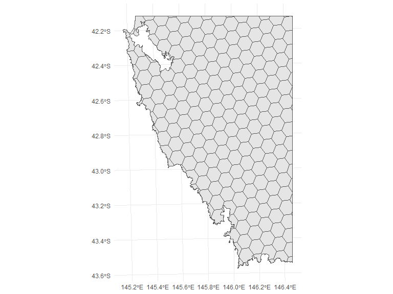

```r
features = tas %>%
  sf::st_drop_geometry() %>%
  dplyr::select(-all_of(c("id", "cost", "locked_in", "locked_out"))) %>%
  names()

# Convert data to binary again
tas <- tas %>%
  mutate(across(all_of(features), ~ if_else(.x > 0, 1, 0)))


#To ease runtime: Crop the study area to a manageable size

bbox <- sf::st_bbox(tas)

frac <- 0.50  # use to adjust the scope of the planning region

bbox_small <- bbox
bbox_small["xmax"] <- bbox["xmin"] + frac * (bbox["xmax"] - bbox["xmin"])
bbox_small["ymax"] <- bbox["ymin"] + frac * (bbox["ymax"] - bbox["ymin"])

tas_small <- sf::st_crop(tas, bbox_small)

tas <- tas_small

#nrow(tas)
# plot planning units
ggplot(tas) +
  geom_sf() +
  theme_minimal() +
  labs(
    x = NULL, y = NULL)
```

For this vignette, we will:

- treat the `cost` column in `tas_pu` as the planning unit cost, and
- aim to represent 30% of each feature’s distribution

Notes: - running the whole dataset at 100% causes Cohon calibration to be severely long - it is worth lookin into it again (at 100%) using a more powerful machine

### Build a baseline prioritizr problem

We first define a **baseline problem** with no explicit fragmentation control:

- **Objective**: minimum set (minimise total cost)
- **Targets**: 30% relative targets for all features
- **Decisions**: binary (each planning unit is either selected or not)
- **Solver**: default solver with a 10% optimality gap

```r
p <- problem(tas, features = features, cost_column = "cost") %>%
  add_min_set_objective() %>%
  add_relative_targets(0.30) %>%  # 30% of each feature
  add_binary_decisions() %>%
  add_cbc_solver(verbose = TRUE)

print(p)
```

```
#> A conservation problem (<ConservationProblem>)
#> ├•data
#> │├•features:    "Banksia.woodlands", "Boulders.rock.with.algae..lichen.or.scattered.plants..or.alpine.fjaeldmarks", "Callitris.forests.and.woodlands", … (33 total)
#> │└•planning units:
#> │ ├•data:       <sf> (223 total)
#> │ ├•costs:      continuous values (between 20.75084 and 45.08766)
#> │ ├•extent:     348703.2, 5175287, 456314.2, 5335459 (xmin, ymin, xmax, ymax)
#> │ └•CRS:        WGS 84 / UTM zone 55S (projected)
#> ├•formulation
#> │├•objective:   minimum set objective
#> │├•penalties:   none specified
#> │├•features:
#> ││├•targets:    relative targets (all equal to 0.3)
#> ││└•weights:    none specified
#> │├•constraints: none specified
#> │└•decisions:   binary decision
#> └•optimization
#>  ├•portfolio:   default portfolio
#>  └•solver:      cbc solver (`gap` = 0.1, `time_limit` = 2147483647, `first_feasible` = FALSE, …)
#> # ℹ Use `summary(...)` to see complete formulation.
```

### Solve the baseline problem

```r
set.seed(1) # for reproducibility

base_time <- system.time({
base_solution <- solve(p)
})

base_time
```

```
#>    user  system elapsed
#>    0.83    0.04    0.94
```

### Plot the baseline solution

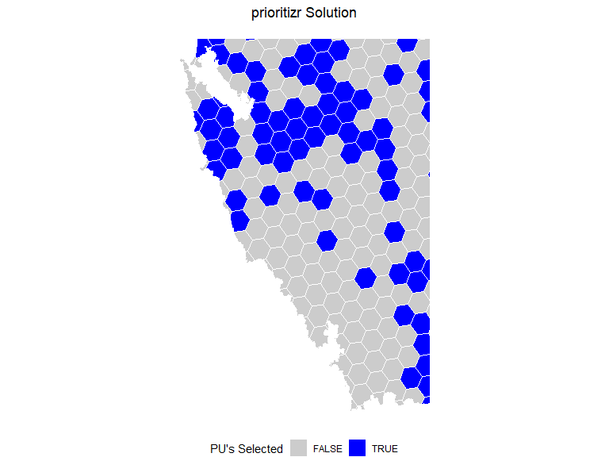

```r
plot_prioritizr(base_solution)
```

In the next sections, we will use this baseline solution to compute fragmentation metrics (e.g., number and size of patches, total boundary length), and then compare it against solutions obtained using boundary penalties and MinPatch.

## Helper: fragmentation metrics

To compare different fragmentation controls, we will use a small helper function to compute summary metrics for each solution. This lets us build a single table of results across all methods.

```r
summarise_solution <- function(label,
                              problem,        # still kept for consistency, but not used now
                              solution_sf,
                              solve_time_sec,
                              min_patch_size = NULL,   # e.g. from MinPatch (m²)
                              boundary_penalty = 0) {  # penalty used in optimisation

  # 1) check & subset selected PUs
  if (!"solution_1" %in% names(solution_sf)) {
    stop("summarise_solution(): column 'solution_1' not found in solution_sf")
  }

  sel <- solution_sf[solution_sf$solution_1 == 1, ]
  n_selected <- nrow(sel)

  # if nothing is selected, return mostly zeros/NA
  if (n_selected == 0) {
    return(tibble(
      method             = label,
      n_selected         = 0L,
      total_area_km2     = 0,
      n_patches          = 0L,
      valid_patches      = NA_integer_,
      median_patch_km2   = NA_real_,
      pu_cost_total      = 0,
      pu_cost_mean       = NA_real_,
      boundary_length_km = 0,
      boundary_cost      = 0,
      total_cost         = 0,
      solver_time_sec    = solve_time_sec
    ))
  }

  # 2) area + patch metrics

  # area of each selected PU (m²)
  pu_areas_m2    <- as.numeric(sf::st_area(sel))
  total_area_km2 <- sum(pu_areas_m2) / 1e6

  # patches = contiguous blobs of selected PUs
  patches <- sel |>
    sf::st_union() |>
    sf::st_cast("POLYGON")

  patch_areas_m2   <- as.numeric(sf::st_area(patches))
  n_patches        <- length(patch_areas_m2)
  median_patch_km2 <- stats::median(patch_areas_m2) / 1e6

  # valid patches if a min patch size is provided
  if (!is.null(min_patch_size)) {
    min_patch_size_m2 <- as.numeric(min_patch_size)
    valid_patches <- sum(patch_areas_m2 >= min_patch_size_m2)
  } else {
    valid_patches <- NA_integer_
  }

  # boundary length (outer boundary of patches, in km)
  patch_boundaries   <- sf::st_cast(sf::st_boundary(patches), "MULTILINESTRING")
  boundary_length_km <- sum(as.numeric(sf::st_length(patch_boundaries))) / 1000

  # 3) cost metrics ---------------------------------------

  if (!"cost" %in% names(solution_sf)) {
    stop("summarise_solution(): column 'cost' not found in solution_sf")
  }

  pu_cost_total <- sum(sel$cost, na.rm = TRUE)
  pu_cost_mean  <- mean(sel$cost, na.rm = TRUE)

  # boundary cost only matters if a penalty was used
  boundary_cost <- boundary_length_km * boundary_penalty
  total_cost    <- pu_cost_total + boundary_cost

  tibble(
    method             = label,
    n_selected         = n_selected,
    total_area_km2     = total_area_km2,
    n_patches          = n_patches,
    valid_patches      = valid_patches,
    median_patch_km2   = median_patch_km2,
    pu_cost_total      = pu_cost_total,
    pu_cost_mean       = pu_cost_mean,
    boundary_length_km = boundary_length_km,
    boundary_cost      = boundary_cost,
    total_cost         = total_cost,
    solver_time_sec    = solve_time_sec
  )
}

# baseline metrics (no min patch size, no boundary penalty)
baseline_metrics <- summarise_solution(
  label            = "baseline",
  problem          = p,
  solution_sf      = base_solution,
  solve_time_sec   = base_time[["elapsed"]],
  min_patch_size   = NULL,
  boundary_penalty = 0
)

baseline_metrics
```

```
#> # A tibble: 1 × 12
#>   method   n_selected total_area_km2 n_patches valid_patches median_patch_km2 pu_cost_total pu_cost_mean boundary_length_km boundary_cost total_cost
#>   <chr>         <int>          <dbl>     <int>         <int>            <dbl>         <dbl>        <dbl>              <dbl>         <dbl>      <dbl>
#> 1 baseline         71          3984.        16            NA             64.9         2191.         30.9              1146.             0      2191.
#> # ℹ 1 more variable: solver_time_sec <dbl>
```

## Approach 1: Manual boundary penalties in prioritizr

### Overview

The baseline solution ignores fragmentation when optimising: the solver only minimises total cost while meeting feature targets. A common way to encourage **more compact** solutions is to add a **boundary penalty** during optimisation.

Here we compare two manually chosen boundary penalties:

- a **low** penalty, which should gently favour more compact patches, and
- a **high** penalty, which should strongly discourage ragged, fragmented solutions.

The downside is that this approach is inherently trial-and-error: it is difficult to predict, from the penalty value alone, how large patches will be or how much cost will increase. Higher penalties can also increase solver runtime, sometimes substantially.

### Run and visualise manual boundary penalties

```r
# low boundary penalty
low_boundary_penalty = 0.00001
p_bp_low <- p |>
  add_boundary_penalties(penalty = low_boundary_penalty)

bp_low_time <- system.time({
  bp_low_solution <- solve(p_bp_low)
})

# high boundary penalty
high_boundary_penalty = 0.0001
p_bp_high <- p |>
  add_boundary_penalties(penalty = high_boundary_penalty)

bp_high_time <- system.time({
  bp_high_solution <- solve(p_bp_high)
})

bp_low_time
```

```
#>    user  system elapsed
#>    1.07    0.03    1.17
```

```r
bp_high_time
```

```
#>    user  system elapsed
#>    3.45    0.01    3.72
```

Visusalise the solutions with low and high boundary penalties

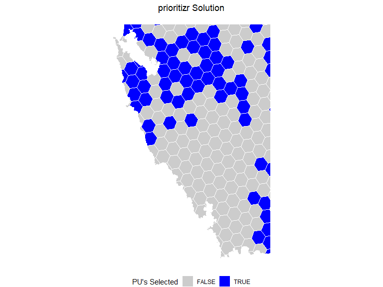

```r
plot_prioritizr(bp_low_solution)
```

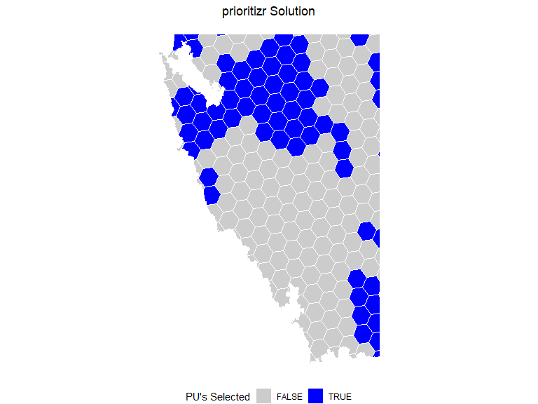

```r
plot_prioritizr(bp_high_solution)
```

### Metrics and interpretation

```r
bp_low_metrics <- summarise_solution(
  label = "manual_bp_low",
  problem = p_bp_low,
  solution_sf = bp_low_solution,
  solve_time_sec = bp_low_time[["elapsed"]],
  boundary_penalty = low_boundary_penalty

)

bp_high_metrics <- summarise_solution(
  label = "manual_bp_high",
  problem = p_bp_high,
  solution_sf = bp_high_solution,
  solve_time_sec = bp_high_time[["elapsed"]],
  boundary_penalty = high_boundary_penalty
)

manual_bp_metrics <- dplyr::bind_rows(
  baseline_metrics,
  bp_low_metrics,
  bp_high_metrics
)

manual_bp_metrics
```

```
#> # A tibble: 3 × 12
#>   method       n_selected total_area_km2 n_patches valid_patches median_patch_km2 pu_cost_total pu_cost_mean boundary_length_km boundary_cost total_cost
#>   <chr>             <int>          <dbl>     <int>         <int>            <dbl>         <dbl>        <dbl>              <dbl>         <dbl>      <dbl>
#> 1 baseline             71          3984.        16            NA             64.9         2191.         30.9              1146.        0           2191.
#> 2 manual_bp_l…         66          3680.        13            NA             64.9         2036.         30.8              1020.        0.0102      2036.
#> 3 manual_bp_h…         70          3847.        11            NA             87.7         2169.         31.0               793.        0.0793      2169.
#> # ℹ 1 more variable: solver_time_sec <dbl>
```

## Approach 2: Automatic calibration with Cohon’s method

### Overview

Choosing boundary penalties by hand can be ad hoc. The function `calibrate_cohon_penalty()` in the *prioritizr* package implements a Cohon-style trade-off calibration. It: 1. Solves the problem for a very chape but fragmented solution 2. Solves the problem for a very compact but expensive solution; and 3. Uses these two anchor solutions to estimate a boundary penalty that balances cost and fragmentation.

### Calibrate and solve

```r
# add a dummy boundary penalty: calibrate_cohon_penalty() will overwrite it
p_bp_cohon <- p |>
  add_boundary_penalties(penalty = 0.0001)

cohon_time <- system.time({
  cohon_penalty <- calibrate_cohon_penalty(
    p_bp_cohon,
    approx  = TRUE,     # approximate mode for speed
    verbose = TRUE
  )
})

cohon_penalty
```

```
#> [1] 0.00242583
#> attr(,"solution_1_objective")
#> [1] 2191.455
#> attr(,"solution_1_penalty")
#> [1] 1034994
#> attr(,"solution_2_objective")
#> [1] 3959.06
#> attr(,"solution_2_penalty")
#> [1] 306333.8
```

```r
cohon_time
```

```
#>    user  system elapsed
#>  306.20    0.97  314.25
```

```r
p_bp_cohon_final <- p |>
  add_boundary_penalties(penalty = cohon_penalty)

bp_cohon_time <- system.time({
  bp_cohon_solution <- solve(p_bp_cohon_final, force = TRUE)
})

bp_cohon_time
```

```
#>    user  system elapsed
#>  250.37    0.55  252.09
```

### Visual comparison

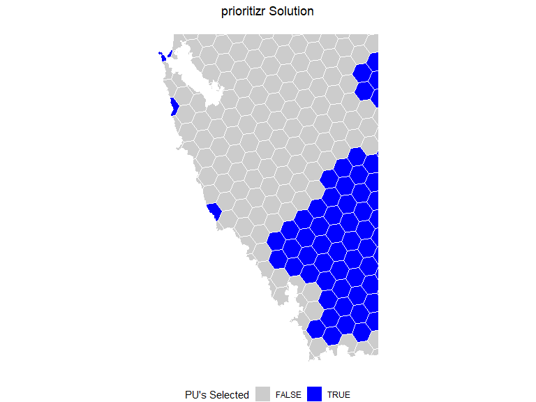

```r
plot_prioritizr(bp_cohon_solution)
```

### Metrics and comparison with manual penalties

```r
cohon_metrics <- summarise_solution(
  label = "cohon_calibrated",
  problem = p_bp_cohon_final,
  solution_sf = bp_cohon_solution,
  solve_time_sec = cohon_time[["elapsed"]] + bp_cohon_time[["elapsed"]],
  min_patch_size   = NULL,
  boundary_penalty = as.numeric(cohon_penalty)  # 👈 use the calibrated value here
)

# bind everything so far for later comparison
fragmentation_metrics <- dplyr::bind_rows(
  baseline_metrics,
  bp_low_metrics,
  bp_high_metrics,
  cohon_metrics
)

fragmentation_metrics
```

```
#> # A tibble: 4 × 12
#>   method       n_selected total_area_km2 n_patches valid_patches median_patch_km2 pu_cost_total pu_cost_mean boundary_length_km boundary_cost total_cost
#>   <chr>             <int>          <dbl>     <int>         <int>            <dbl>         <dbl>        <dbl>              <dbl>         <dbl>      <dbl>
#> 1 baseline             71          3984.        16            NA             64.9         2191.         30.9              1146.        0           2191.
#> 2 manual_bp_l…         66          3680.        13            NA             64.9         2036.         30.8              1020.        0.0102      2036.
#> 3 manual_bp_h…         70          3847.        11            NA             87.7         2169.         31.0               793.        0.0793      2169.
#> 4 cohon_calib…         66          3563.         7            NA             25.6         2218.         33.6               462.        1.12        2219.
#> # ℹ 1 more variable: solver_time_sec <dbl>
```

## Approach 3: MinPatch – minimum patch size only

### Overview

Boundary penalties influence fragmentation **during** optimisation. In contrast, the *minpatch* package reduces fragmentation **after** optimisation by enforcing a **minimum patch size** on an existing solution.

### Set MinPatch parameters

```r
# median planning-unit area
median_area <- stats::median(sf::st_area(tas))

# set minimum patch size to 5x the median planning-unit area
min_patch_size <- median_area * 5

# set patch radius to roughly encompass 10 planning units
patch_radius <- sqrt(as.numeric(median_area) * 10)

cat("MinPatch parameters:\n")
```

```
#> MinPatch parameters:
```

```r
cat("- Minimum patch size:", round(min_patch_size, 3), "square meters\n")
```

```
#> - Minimum patch size: 324530226 square meters
```

```r
cat("- Patch radius:", round(patch_radius, 3), "meters\n")
```

```
#> - Patch radius: 25476.67 meters
```

```r
cat("- This means patches must be at least",
    round(min_patch_size / median_area, 3),
    "times the median planning unit size\n")
```

```
#> - This means patches must be at least 5 times the median planning unit size
```

### Run MinPatch on the baseline solution

```r
# time MinPatch processing
minpatch_time_3 <- system.time({
  mp3_result <- run_minpatch(
    prioritizr_problem   = p,
    prioritizr_solution  = base_solution,             # baseline prioritizr solution
    min_patch_size       = min_patch_size,
    patch_radius         = patch_radius,
    boundary_penalty     = 0,             # no boundary penalty inside MinPatch
    remove_small_patches = TRUE,
    add_patches          = TRUE,
    whittle_patches      = TRUE,
    verbose              = TRUE
  )
})
```

```
#> Validating inputs...
#> Initializing data structures...
#> Calculating boundary matrix (this may take a while)...
#> Processed 100 of 223 planning units
#> Processed 200 of 223 planning units
#> Creating patch radius dictionary...
#> Processed 100 of 223 planning units
#> Processed 200 of 223 planning units
#> Calculating initial patch statistics...
#> Stage 1: Removing small patches...
#> Stage 2: Adding new patches...
#>   Initial unmet targets: 20
#>   Unmet feature IDs: 2, 4, 5, 6, 8, 9, 10, 13, 14, 16, 18, 20, 24, 25, 26, 27, 30, 31, 32, 33
#>   Iteration 1 - Unmet targets: 20
#>     Found 171 potential patches with scores
#>     Best score: 0.03269313 for unit 7
#>     Added patch centered on unit 7
#>   Iteration 2 - Unmet targets: 12
#>     Found 160 potential patches with scores
#>     Best score: 0.02006819 for unit 15
#>     Added patch centered on unit 15
#>   Iteration 3 - Unmet targets: 4
#>     Found 141 potential patches with scores
#>     Best score: 0.005825508 for unit 52
#>     Added patch centered on unit 52
#>   Iteration 4 - Unmet targets: 3
#>     Found 132 potential patches with scores
#>     Best score: 0.004038806 for unit 8
#>     Added patch centered on unit 8
#>   Iteration 5 - Unmet targets: 2
#>     Found 78 potential patches with scores
#>     Best score: 0.003498923 for unit 91
#>     Added patch centered on unit 91
#>   All conservation targets are now met!
#> Stage 3: Removing unnecessary planning units...
#>     Edge units found: 113
#>     Keystone units: 0
#>     New keystone units: 4
#>     Scoreable units: 109
#>     Removed unit 17 at iteration 1
```

[output cut: 112 more lines]

[output not shown]

```r
minpatch_time_3
```

```
#>    user  system elapsed
#>  220.30    5.22  226.73
```

### Visualise and summarise MinPatch (patch size only)

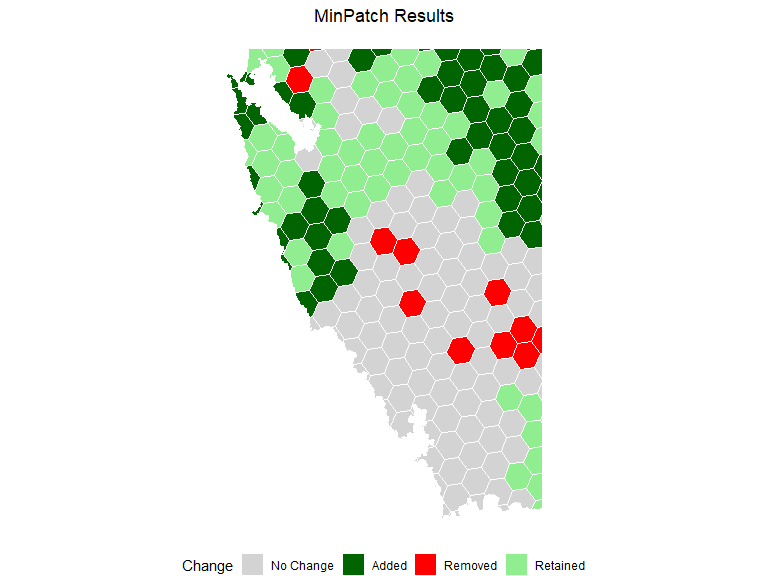

```r
plot_minpatch(mp3_result, title = "MinPatch Results")
```

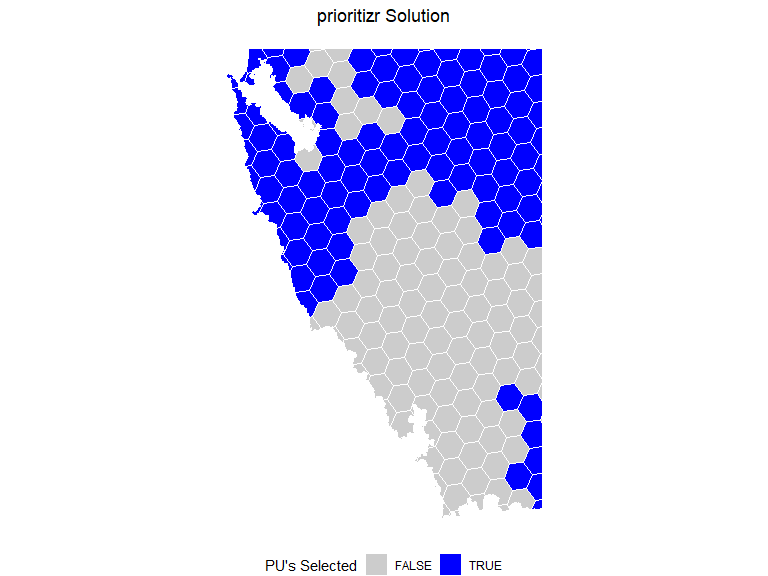

```r
mp3_solution <- mp3_result$solution
mp3_solution <- mp3_solution |>
  dplyr::rename(solution_1 = minpatch)

plot_prioritizr(mp3_solution)
```

```r
mp3_metrics <- summarise_solution(
  label            = "minpatch_min_size",
  problem          = p,
  solution_sf      = mp3_solution,          # output from minpatch
  solve_time_sec   = minpatch_time_3[["elapsed"]],
  min_patch_size   = min_patch_size,
  boundary_penalty = 0                         # no boundary penalty used
)

mp3_metrics
```

```
#> # A tibble: 1 × 12
#>   method       n_selected total_area_km2 n_patches valid_patches median_patch_km2 pu_cost_total pu_cost_mean boundary_length_km boundary_cost total_cost
#>   <chr>             <int>          <dbl>     <int>         <int>            <dbl>         <dbl>        <dbl>              <dbl>         <dbl>      <dbl>
#> 1 minpatch_mi…        112          5797.         7             2           0.0283         3689.         32.9               896.             0      3689.
#> # ℹ 1 more variable: solver_time_sec <dbl>
```

```r
fragmentation_metrics <- dplyr::bind_rows(
  fragmentation_metrics, # change to fragmentation_metrics once Cohon works
  mp3_metrics
)

fragmentation_metrics
```

```
#> # A tibble: 5 × 12
#>   method       n_selected total_area_km2 n_patches valid_patches median_patch_km2 pu_cost_total pu_cost_mean boundary_length_km boundary_cost total_cost
#>   <chr>             <int>          <dbl>     <int>         <int>            <dbl>         <dbl>        <dbl>              <dbl>         <dbl>      <dbl>
#> 1 baseline             71          3984.        16            NA          64.9            2191.         30.9              1146.        0           2191.
#> 2 manual_bp_l…         66          3680.        13            NA          64.9            2036.         30.8              1020.        0.0102      2036.
#> 3 manual_bp_h…         70          3847.        11            NA          87.7            2169.         31.0               793.        0.0793      2169.
#> 4 cohon_calib…         66          3563.         7            NA          25.6            2218.         33.6               462.        1.12        2219.
#> 5 minpatch_mi…        112          5797.         7             2           0.0283         3689.         32.9               896.        0           3689.
#> # ℹ 1 more variable: solver_time_sec <dbl>
```

We can see from the table that the runtime and the total cost is significantly higher than the manual boundary approach. However, the number of contiguous patches is less, making the solution more compact.

## Approach 4: MinPatch – minimum patch size with boundary penalty

### Overview

MinPatch can also use a **boundary penalty** in its final whittling stage. This does not change the minimum patch size requirement, but it can influence **which edge units are removed or retained**, potentially leading to smoother patch shapes.

Here we repeat Approach 3, but add a small positive boundary penalty inside MinPatch.

### Run and visualise MinPatch with boundary penalty

```r
minpatch_time_4 <- system.time({
  mp4_result <- run_minpatch(
    prioritizr_problem   = p,
    prioritizr_solution  = base_solution,           # same baseline prioritizr solution
    min_patch_size       = min_patch_size,
    patch_radius         = patch_radius,
    boundary_penalty     = 0.0001,       # small positive penalty for ragged edges
    remove_small_patches = TRUE,
    add_patches          = TRUE,
    whittle_patches      = TRUE,
    verbose              = TRUE
  )
})
```

```
#> Validating inputs...
#> Initializing data structures...
#> Calculating boundary matrix (this may take a while)...
#> Processed 100 of 223 planning units
#> Processed 200 of 223 planning units
#> Creating patch radius dictionary...
#> Processed 100 of 223 planning units
#> Processed 200 of 223 planning units
#> Calculating initial patch statistics...
#> Stage 1: Removing small patches...
#> Stage 2: Adding new patches...
#>   Initial unmet targets: 20
#>   Unmet feature IDs: 2, 4, 5, 6, 8, 9, 10, 13, 14, 16, 18, 20, 24, 25, 26, 27, 30, 31, 32, 33
#>   Iteration 1 - Unmet targets: 20
#>     Found 171 potential patches with scores
#>     Best score: 0.03269313 for unit 7
#>     Added patch centered on unit 7
#>   Iteration 2 - Unmet targets: 12
#>     Found 160 potential patches with scores
#>     Best score: 0.02006819 for unit 15
#>     Added patch centered on unit 15
#>   Iteration 3 - Unmet targets: 4
#>     Found 141 potential patches with scores
#>     Best score: 0.005825508 for unit 52
#>     Added patch centered on unit 52
#>   Iteration 4 - Unmet targets: 3
#>     Found 132 potential patches with scores
#>     Best score: 0.004038806 for unit 8
#>     Added patch centered on unit 8
#>   Iteration 5 - Unmet targets: 2
#>     Found 78 potential patches with scores
#>     Best score: 0.003498923 for unit 91
#>     Added patch centered on unit 91
#>   All conservation targets are now met!
#> Stage 3: Removing unnecessary planning units...
#>     Edge units found: 113
#>     Keystone units: 0
#>     New keystone units: 4
#>     Scoreable units: 109
#>     Removed unit 17 at iteration 1
```

[output cut: 112 more lines]

[output not shown]

```r
minpatch_time_4
```

```
#>    user  system elapsed
#>  218.29    6.00  227.40
```

```r
# (so summarise_solution() can reuse its logic)
mp4_solution <- tas |>
  dplyr::mutate(solution_1 = mp4_result$solution$minpatch)
```

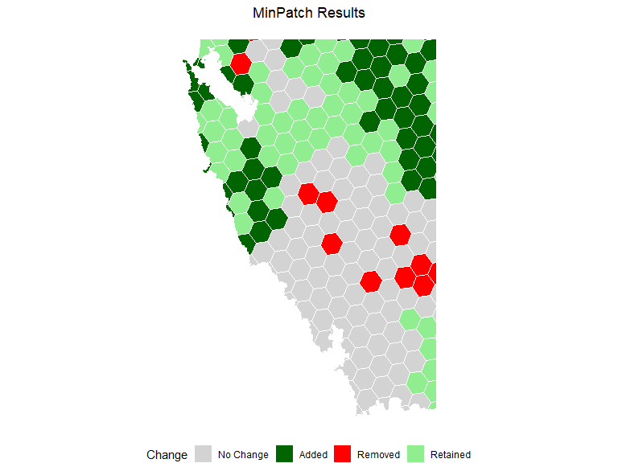

```r
plot_minpatch(mp4_result, title = "MinPatch Results")
```

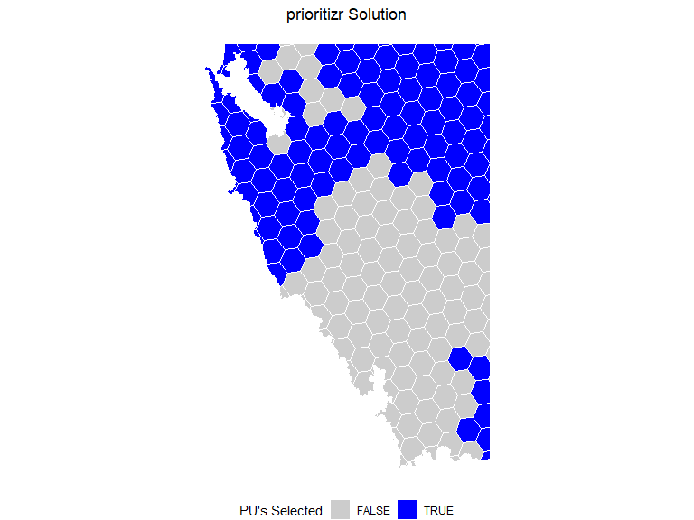

```r
mp4_solution <- mp4_result$solution
mp4_solution <- mp4_solution |>
  dplyr::rename(solution_1 = minpatch)

plot_prioritizr(mp4_solution)
```

### Metrics and adding to the summary table

```r
mp4_metrics <- summarise_solution(
  label = "minpatch_min_size_bp",
  problem = p,
  solution_sf = mp4_solution,
  solve_time_sec = minpatch_time_4[["elapsed"]],
  min_patch_size = min_patch_size,
  boundary_penalty = 1
)

mp4_metrics
```

```
#> # A tibble: 1 × 12
#>   method       n_selected total_area_km2 n_patches valid_patches median_patch_km2 pu_cost_total pu_cost_mean boundary_length_km boundary_cost total_cost
#>   <chr>             <int>          <dbl>     <int>         <int>            <dbl>         <dbl>        <dbl>              <dbl>         <dbl>      <dbl>
#> 1 minpatch_mi…        112          5797.         7             2           0.0283         3689.         32.9               896.          896.      4584.
#> # ℹ 1 more variable: solver_time_sec <dbl>
```

```r
fragmentation_metrics <- dplyr::bind_rows(
  fragmentation_metrics,
  mp4_metrics
)

fragmentation_metrics
```

```
#> # A tibble: 6 × 12
#>   method       n_selected total_area_km2 n_patches valid_patches median_patch_km2 pu_cost_total pu_cost_mean boundary_length_km boundary_cost total_cost
#>   <chr>             <int>          <dbl>     <int>         <int>            <dbl>         <dbl>        <dbl>              <dbl>         <dbl>      <dbl>
#> 1 baseline             71          3984.        16            NA          64.9            2191.         30.9              1146.        0           2191.
#> 2 manual_bp_l…         66          3680.        13            NA          64.9            2036.         30.8              1020.        0.0102      2036.
#> 3 manual_bp_h…         70          3847.        11            NA          87.7            2169.         31.0               793.        0.0793      2169.
#> 4 cohon_calib…         66          3563.         7            NA          25.6            2218.         33.6               462.        1.12        2219.
#> 5 minpatch_mi…        112          5797.         7             2           0.0283         3689.         32.9               896.        0           3689.
#> 6 minpatch_mi…        112          5797.         7             2           0.0283         3689.         32.9               896.      896.          4584.
#> # ℹ 1 more variable: solver_time_sec <dbl>
```

## Summary comparison

```r
fragmentation_metrics |>
  dplyr::arrange(boundary_length_km) |>
  knitr::kable(
    digits = 2,
    caption = "Summary of fragmentation metrics across all approaches."
  )
```

Summary of fragmentation metrics across all approaches.

| method | n_selected | total_area_km2 | n_patches | valid_patches | median_patch_km2 | pu_cost_total | pu_cost_mean | boundary_length_km | boundary_cost | total_cost | solver_time_sec |
| --- | --- | --- | --- | --- | --- | --- | --- | --- | --- | --- | --- |
| cohon_calibrated | 66 | 3562.98 | 7 | NA | 25.56 | 2217.60 | 33.60 | 461.61 | 1.12 | 2218.72 | 566.34 |
| manual_bp_high | 70 | 3847.20 | 11 | NA | 87.68 | 2169.32 | 30.99 | 793.29 | 0.08 | 2169.40 | 3.72 |
| minpatch_min_size | 112 | 5796.61 | 7 | 2 | 0.03 | 3688.53 | 32.93 | 895.89 | 0.00 | 3688.53 | 226.73 |
| minpatch_min_size_bp | 112 | 5796.61 | 7 | 2 | 0.03 | 3688.53 | 32.93 | 895.89 | 895.89 | 4584.43 | 227.40 |
| manual_bp_low | 66 | 3680.24 | 13 | NA | 64.92 | 2035.91 | 30.85 | 1019.52 | 0.01 | 2035.92 | 1.17 |
| baseline | 71 | 3984.22 | 16 | NA | 64.92 | 2191.45 | 30.87 | 1145.61 | 0.00 | 2191.45 | 0.94 |

### Side-by-side map comparison

To compare the spatial patterns directly, we can arrange all solutions in a single panel using **patchwork**:

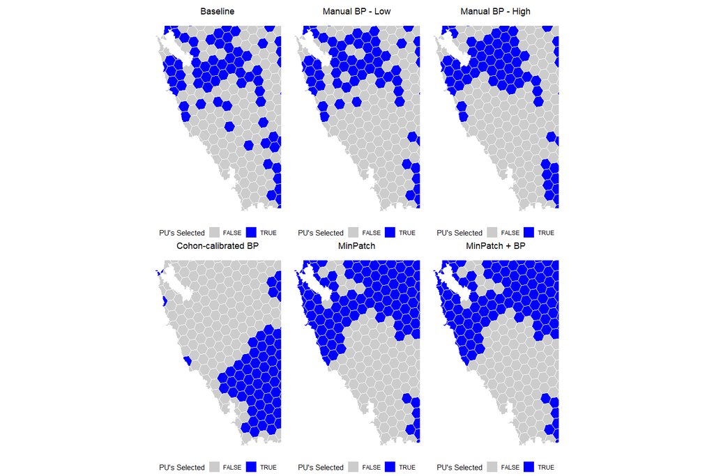

```r
# make sure each call returns a ggplot object
p_base   <- plot_prioritizr(base_solution)       + ggtitle("Baseline")
p_low    <- plot_prioritizr(bp_low_solution)     + ggtitle("Manual BP - Low")
p_high   <- plot_prioritizr(bp_high_solution)    + ggtitle("Manual BP - High")
p_cohon  <- plot_prioritizr(bp_cohon_solution)   + ggtitle("Cohon-calibrated BP")
p_mp3    <- plot_prioritizr(mp3_solution)   + ggtitle("MinPatch")
p_mp4    <- plot_prioritizr(mp4_solution)   + ggtitle("MinPatch + BP")

# arrange in a 2 x 3 grid
(p_base | p_low | p_high) /
(p_cohon | p_mp3 | p_mp4)
```

### Cost–fragmentation trade-off

In this plot, points further left have more compact solutions (short boundaries), and points further down are cheaper. The different approaches occupy different parts of this trade-off space, which helps to clarify when manual penalties, automatic calibration, or MinPatch post-processing might be most useful in a practical workflow.

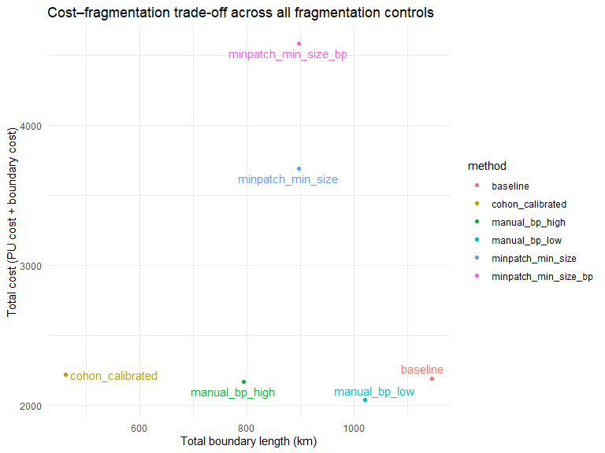

```r
ggplot(fragmentation_metrics,
       aes(x = boundary_length_km, y = total_cost,
           colour = method, label = method)) +
  geom_point() +
  ggrepel::geom_text_repel(show.legend = FALSE) +
  theme_minimal() +
  labs(
    x = "Total boundary length (km)",
    y = "Total cost (PU cost + boundary cost)",
    title = "Cost–fragmentation trade-off across all fragmentation controls"
  )
```

### Table summary

| Approach | Method | Pros | Cons |
| --- | --- | --- | --- |
| 1 | Manual boundary penalties (*prioritizr*) | Simple; low runtime; easy to implement | Trial-and-error; arbitrary penalty choice; solution patchiness highly sensitive to penalty |
| 2 | Calibrated boundary penalties (`calibrate_cohon_penalty()`) | Systematic trade-off between cost and compactness; reduced subjectivity | High runtime; computationally expensive |
| 3 | Minimum patch size rules (*minpatch*) | Explicit control over patch size; more contiguous solutions; moderate runtime | Depends on chosen minimum patch size; may be less cost-optimal |
| 4 | Boundary penalties within MinPatch | Possibly more precise than Approach 3 | Little to no effect; solutions similar to Approach 3 |